# Assignment 1

Pang Woon Yen S2036711

04/04/2021

## Walmart Sales Data Analysis

### Introduction

**Data frame** is a table of two dimensions which form a spreadsheet in R.  
It contains rows and columns.  
Each **row** (horizontally) is the values set obtained from one **observation** or what we called data subject, for instance, a car is one of the observation.  
On the other hand, a **column** (vertically) is the **attribute** or what we called variable, where it should contain the same data type and same information, for example, car age is a characteristic to describe a car.  
A dataset of Walmart’s sales data has been gotten from Kaggle. (URL: https://www.kaggle.com/vik2012kvs/walmart-dataretail-analysis/tasks?taskId=2434) The dataset covers historical sales from 2010-02-05 to 2021-11-01 rom 45 Walmart stores in the United States. Within this dataset, we can find 8 fields or attributes, namely:  
1. *Store* - the store number  
2. *Date* - the week of sales  
3. *Weekly_Sales* - sales amount for the given store  
4. *Holiday_Flag* - whether the week is a special holiday week 1 - Holiday week, 0 - Non-holiday week  
5. *Temperature* - Temperature on the day of sale  
6. *Fuel_Price* - Cost of fuel in the region  
7. *CPI* - Prevailing consumer price index  
8. *Unemployment* - Prevailing unemployment rate  
There are **6435 observations** in this dataset. We will subset it by selecting only **5 stores** and the date to be within the year of **2011** only.

### Packages Info

There are several R packages to be installed beforehand.  
1. dplyr  
2. reshape2  
3. ggplot2  
4. scales  
5. corrplot  
6. sqldf  
dplyr: a grammar of data manipulation - commonly used to mutate a new variable or to summarise multiple rows into single rows by grouping categories. The functions “group_by” and “summarise” are used in this assignment to summarise the weekly sales according to months and stores.  
reshape2: a package mainly used to transform data between long and wide format - long format data is without id-variable, using all as measure variables, the data frame has less columns, whereas, wide format data has a column for each variable.  
For instance, long format data:

```r
df <- data.frame(store=c("A","A","B","B"),week=c(1,2,1,2), value=c(10,50,20,30))
print(df)
```

```
##   store week value
## 1     A    1    10
## 2     A    2    50
## 3     B    1    20
## 4     B    2    30
```

Wide format data:

```r
df <- data.frame(store=c("A","B"), week_1=c(10,20), week_2=c(50,30))
print(df)
```

```
##   store week_1 week_2
## 1     A     10     50
## 2     B     20     30
```

*reshape2* provides functions such as melt() and cast() - *melt* turns wide format data into long format data, *cast* turns long format data into wide format data.  
ggplot2: for data visualisation - ggplot() allows us to customise which kind of graphs (line chart,bar chart etc) to show by selecting the x-axis, y-axis, title and customise the color and layout.  
scales: a package for scaling, converting from data values to perceptual properties. It is usually used to customise the appearance of axis and legend labels by using *break* function and *label* function.  
corrplot: to display graphical correlation matrix and confidence interval, could be used to determine the correlations between numerical variables.  
sqldf: to execute queries in R, using select…from data where condition and so on. Good to retrieve data and summarise data.

Load the packages that we need for data analysis later.

```r
#load the packages which be needed for data analysis later on

library(dplyr)
```

```r
library(reshape2)
library(ggplot2)
library(scales)
library(corrplot)
library(sqldf)
```

### Data Preparation

First, import the dataset to be a data frame and name it “**Sales**”

```r
Sales <- read.csv("./Walmart_Store_sales.csv", header=T)
print(head(Sales)) #show the sample of the dataset
```

```
##   Store       Date Weekly_Sales Holiday_Flag Temperature Fuel_Price      CPI
## 1     1 05-02-2010      1643691            0       42.31      2.572 211.0964
## 2     1 12-02-2010      1641957            1       38.51      2.548 211.2422
## 3     1 19-02-2010      1611968            0       39.93      2.514 211.2891
## 4     1 26-02-2010      1409728            0       46.63      2.561 211.3196
## 5     1 05-03-2010      1554807            0       46.50      2.625 211.3501
## 6     1 12-03-2010      1439542            0       57.79      2.667 211.3806
##   Unemployment
## 1        8.106
## 2        8.106
## 3        8.106
## 4        8.106
## 5        8.106
## 6        8.106
```

Above shown is the *first 6 rows* of the dataset.  
Let’s examine the structure of the data imported.

```r
str(Sales)
```

```
## 'data.frame':    6435 obs. of  8 variables:
##  $ Store       : int  1 1 1 1 1 1 1 1 1 1 ...
##  $ Date        : chr  "05-02-2010" "12-02-2010" "19-02-2010" "26-02-2010" ...
##  $ Weekly_Sales: num  1643691 1641957 1611968 1409728 1554807 ...
##  $ Holiday_Flag: int  0 1 0 0 0 0 0 0 0 0 ...
##  $ Temperature : num  42.3 38.5 39.9 46.6 46.5 ...
##  $ Fuel_Price  : num  2.57 2.55 2.51 2.56 2.62 ...
##  $ CPI         : num  211 211 211 211 211 ...
##  $ Unemployment: num  8.11 8.11 8.11 8.11 8.11 ...
```

Reformatting the data type of *Store* to be factor, *Date* to be date and *Holiday_Flag* to be factor.

```r
Sales$Store <-as.factor(Sales$Store)
Sales[[2]] <- as.Date(Sales$Date, "%d-%m-%Y")
Sales$Holiday_Flag <- as.factor(Sales$Holiday_Flag)
str(Sales)
```

```
## 'data.frame':    6435 obs. of  8 variables:
##  $ Store       : Factor w/ 45 levels "1","2","3","4",..: 1 1 1 1 1 1 1 1 1 1 ...
##  $ Date        : Date, format: "2010-02-05" "2010-02-12" ...
##  $ Weekly_Sales: num  1643691 1641957 1611968 1409728 1554807 ...
##  $ Holiday_Flag: Factor w/ 2 levels "0","1": 1 2 1 1 1 1 1 1 1 1 ...
##  $ Temperature : num  42.3 38.5 39.9 46.6 46.5 ...
##  $ Fuel_Price  : num  2.57 2.55 2.51 2.56 2.62 ...
##  $ CPI         : num  211 211 211 211 211 ...
##  $ Unemployment: num  8.11 8.11 8.11 8.11 8.11 ...
```

Now, we are going to subset the dataset to be 5 randomly chosen stores, and the date of sales to be in 2011.

```r
## random_numbers <- sample(1:45, 5, replace=F)
## print(random_numbers)
random_numbers <- c(9, 11, 26, 36, 40)
Sales_subset <- subset(Sales,Store %in% random_numbers & Date >= "2011-01-01" & Date <= "2011-12-31")
Sales_subset$Store <- droplevels(Sales_subset$Store)
str(Sales_subset)
```

```
## 'data.frame':    260 obs. of  8 variables:
##  $ Store       : Factor w/ 5 levels "9","11","26",..: 1 1 1 1 1 1 1 1 1 1 ...
##  $ Date        : Date, format: "2011-01-07" "2011-01-14" ...
##  $ Weekly_Sales: num  490982 458087 454022 463561 544612 ...
##  $ Holiday_Flag: Factor w/ 2 levels "0","1": 1 1 1 1 1 2 1 1 1 1 ...
##  $ Temperature : num  41.8 36.4 44.7 43.9 31.8 ...
##  $ Fuel_Price  : num  2.98 2.98 3.02 3.01 2.99 ...
##  $ CPI         : num  215 215 215 216 216 ...
##  $ Unemployment: num  6.42 6.42 6.42 6.42 6.42 ...
```

Next, relabel the levels in *Holiday_Flag* to be “Yes” and “No”

```r
levels(Sales_subset$Holiday_Flag) <- c("No", "Yes")
Sales_subset$Holiday_Flag <- factor(Sales_subset$Holiday_Flag, c("Yes","No"))
str(Sales_subset$Holiday_Flag)
```

```
##  Factor w/ 2 levels "Yes","No": 2 2 2 2 2 1 2 2 2 2 ...
```

Let’s have a look on the summary of variables

```r
summary(Sales_subset)
```

```
##  Store        Date             Weekly_Sales     Holiday_Flag  Temperature
##  9 :52   Min.   :2011-01-07   Min.   : 287425   Yes: 20      Min.   : 5.54
##  11:52   1st Qu.:2011-04-06   1st Qu.: 517144   No :240      1st Qu.:45.17
##  26:52   Median :2011-07-04   Median : 909576                Median :62.40
##  36:52   Mean   :2011-07-04   Mean   : 848354                Mean   :59.24
##  40:52   3rd Qu.:2011-10-01   3rd Qu.:1089248                3rd Qu.:75.58
##          Max.   :2011-12-30   Max.   :2213519                Max.   :91.63
##    Fuel_Price         CPI         Unemployment
##  Min.   :2.942   Min.   :132.9   Min.   :4.420
##  1st Qu.:3.284   1st Qu.:136.2   1st Qu.:6.298
##  Median :3.536   Median :214.3   Median :7.567
##  Mean   :3.520   Mean   :184.6   Mean   :6.883
##  3rd Qu.:3.759   3rd Qu.:218.7   3rd Qu.:7.767
##  Max.   :4.101   Max.   :223.2   Max.   :8.395
```

### Data Analysis

Now we have the sales data on a *weekly basis*, aggregation would allow us to get the **annual sales** for every outlet.

```r
Annual_Sales <- aggregate(Sales_subset$Weekly_Sales, by=list(Store=Sales_subset$Store), FUN=sum)

#Rename the column name
colnames(Annual_Sales) <- c("Store", "Annual Sales")

#Sort the data to display the annual sales from highest to lowest
Annual_Sales <- Annual_Sales[order(Annual_Sales$`Annual Sales`, decreasing=T),]
print(Annual_Sales)
```

```
##   Store Annual Sales
## 2    11     70523583
## 3    26     52049252
## 5    40     50340543
## 1     9     28685970
## 4    36     18972619
```

From the table shown above, first row has the **highest sales** generated in 2011 among these 5 randomly picked stores.  
Next, we can also get the monthly sales data.

```r
#create a new data frame with monthly sales data
Monthly_Sales <- Sales_subset %>%
  group_by(Store, Month = months(Date)) %>%
  summarise(Monthly_Sales = sum(Weekly_Sales))
#rearrange the month in chronological order
Monthly_Sales$Month = factor(Monthly_Sales$Month, levels = month.name)


#transform the Monthly_Sales data frame to wide format
dcast(Monthly_Sales, Store ~ Month)
```

```
##   Store January February   March   April     May    June    July  August
## 1     9 1866652  2223984 2072514 2692737 2156478 2234498 2548781 2158647
## 2    11 4661550  5720529 5335605 6644689 5065756 5250358 6402162 5546264
## 3    26 3377791  3814795 3646250 4492878 3900845 4127634 5248689 4281581
## 4    36 1566523  1626477 1632231 1944670 1513557 1502541 1833039 1479438
## 5    40 3205521  3693765 3542972 4476392 3800101 4008550 5019224 3932174
##   September October November December
## 1   2589013 2188955  2549597  3404114
## 2   6244339 5268452  5988386  8395491
## 3   4944408 4065073  4295003  5854303
## 4   1683661 1323042  1307600  1559840
## 5   4658793 3891137  4184420  5927495
```

Let’s visualise the **monthly sales data by stores**!

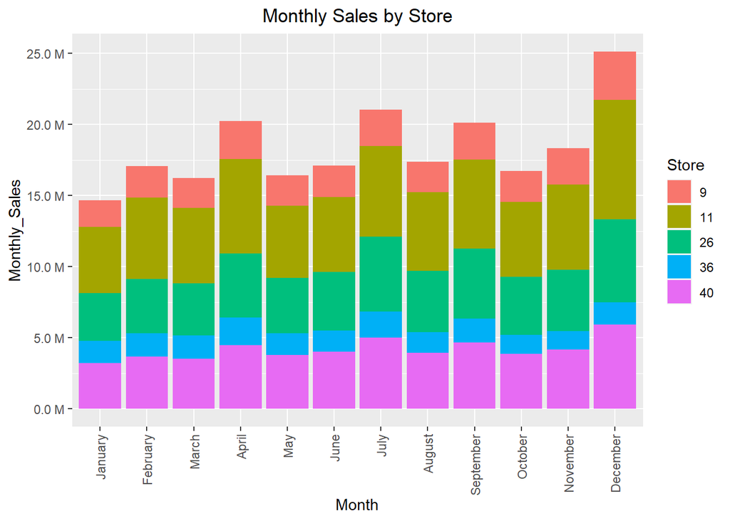

```r
#plot a line graph to show monthly sales
ggplot(data = Monthly_Sales, aes(fill=Store, y=Monthly_Sales, x=Month)) + geom_bar(position="stack", stat="identity") + labs(title = "Monthly Sales by Store") + expand_limits(y=0) + scale_y_continuous(labels=unit_format(unit = "M", scale=1e-6)) +theme(axis.text.x = element_text(angle=90, vjust=0.5, hjust=1), plot.title=element_text(hjust=0.5))
```

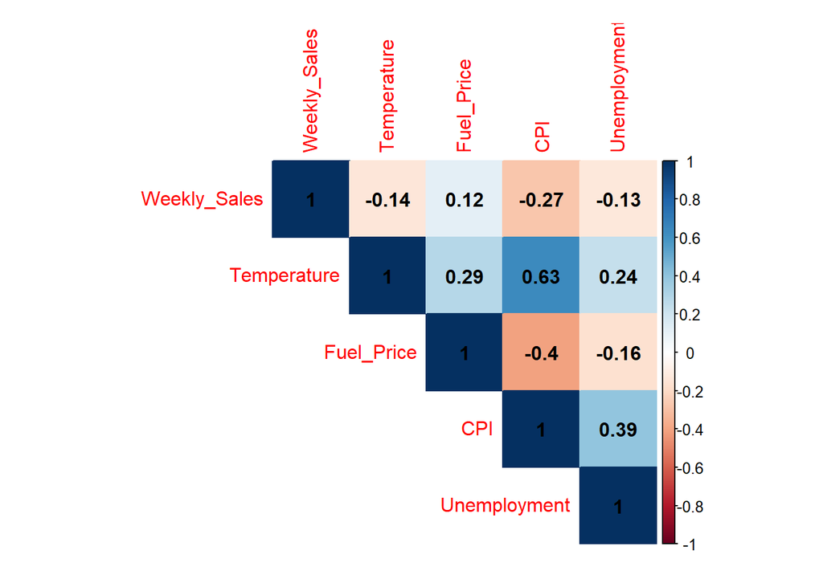

```r
#create a new data frame with only numerical variables for correlation matrix purpose
Sales_subset_corr <- Sales_subset[, c(3,5,6,7,8)]
corrplot(cor(Sales_subset_corr), method="color", type="upper", addCoef.col = "black", mar=c(1,1,1,1))
```

```r
#find the mean and standard deviation by groups
Sales_subset %>% group_by(Store) %>% summarise(Mean_sales = mean(Weekly_Sales), Std_dev = sd(Weekly_Sales, na.rm=F))
```

```
## # A tibble: 5 x 3
##   Store Mean_sales Std_dev
##   <fct>      <dbl>   <dbl>
## 1 9        551653.  76428.
## 2 11      1356223. 181276.
## 3 26      1000947. 120973.
## 4 36       364858.  35902.
## 5 40       968087. 131965.
```

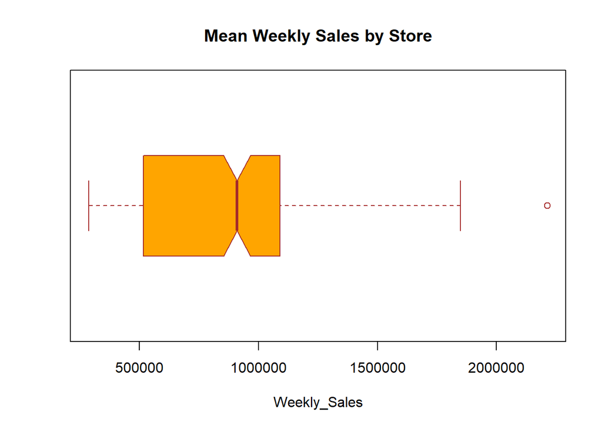

```r
#draw a boxplot to see whether there is outlier in the weekly sales
boxplot(Sales_subset$Weekly_Sales, main= "Mean Weekly Sales by Store",
        xlab="Weekly_Sales", col="orange", border="brown", horizontal=T, notch=T)
```

```r
#print the maximum weekly sales which is the outlier
print(Sales_subset[which.max(Sales_subset$Weekly_Sales), c(1,3)])
```

```
##      Store Weekly_Sales
## 1529    11      2213519
```

The boxplot shows that there is an outlier above the 75th percentile. Based on the maximum weekly sales we have in the data, the outlier was from Store 11 with *$2,213,519* sales achieved, which is far beyond any other weekly sales.  
As a retailer, we should be curious on whether a holiday affects the sales generated? It could be taken as a strategic decision on having more promotions on a holiday week or not.

```r
Sales_by_Holiday <- Sales_subset %>% group_by(Holiday_Flag) %>% summarise(Average_Sales = mean(Weekly_Sales))

print(Sales_by_Holiday)
```

```
## # A tibble: 2 x 2
##   Holiday_Flag Average_Sales
##   <fct>                <dbl>
## 1 Yes                906040.
## 2 No                 843547.
```

```r
#Calculate the percentage of gap between the 2 categories
max_sales <- max(Sales_by_Holiday$Average_Sales)
min_sales <- min(Sales_by_Holiday$Average_Sales)
difference_sales <- (max_sales-min_sales)/min_sales
label_percent()(difference_sales)
```

```
## [1] "7%"
```

Apparently, on average, the stores generate higher sales if there is a holiday within that particular week, with a *7%* difference as compared to normal week. This suggested that more people tend to visit retail outlets during the week with holidays. Retailer can take the opportunity to do promotion over the week with holidays.

```r
sqldf("select Store, max(Weekly_Sales) as Sales, Holiday_Flag, Date from Sales_subset group by Store")
```

```
##   Store     Sales Holiday_Flag       Date
## 1    11 2213518.5           No 2011-12-23
## 2    26 1515175.0           No 2011-12-23
## 3    36  431412.2           No 2011-03-18
## 4    40 1601585.7           No 2011-12-23
## 5     9  905324.7           No 2011-12-23
```

Last but not least, 4 out of these 5 stores had *highest weekly sales* on the week of 23 Dec 2011, which is 2 days before *Christmas*. People tend to spend more for Christmas in the United States as it is a popular festive season. The maximum sales of Store 36 is the *lowest* among these 5 stores, and it happened on the week of 18 March 2011. This is a surprise result which out of our expectation.  
In a nutshell, Walmart generally perform better in December due to Christmas festive season and Store 11 has achieved *highest sales* over the months in 2011 as compared to other stores. Other variables in the dataset do not correlate much to the weekly sales of each store. We shall look into other factors like *location*, *size of the outlet* etc would affect the sales.